# MTH 209 Data Manipulation and Management

Lesson 9: R Programming Structures

Ying-Ju Tessa Chen  
ychen4@udayton.edu  
University of Dayton

# Overview

In this session, we will talk about R programming structures including

- Control Statements
- Creation of Functions
- Recursion

**Note:** This lesson is based on the book: The Art of R Programming ((Matloff 2011)).

# Control Statements - 1

- Loops

Loops can be used when repetitive operations are needed. Using loops helps to make the code more readable. However, programming in R is particularly slow when multiple loops are used. Writing pseudo code to plan your algorithm may help to reduce the number of loops needed in the computation.

There are three main types of loop in R: the for() loop, the while() loop and the repeat loop.

### for loop statement

for() loops are used for general purposes. This means we should know the number of iterations needed.

```
for (variable in sequence){
    statments
}
```

### while loop statement

```
while (condition){
    statments
}
```

We will introduce the repeat loop after talking about if-else statement.

# Control Statements - 2

**Example**: Give $n=100$, find $1\times 2+2\times 3 + \cdots + n\times (n+1)$.

```r
total_for<- 0
n <- 100
for (i in 1:n){
  total_for <- total_for + i*(i+1)
}
total_for
```

```
## [1] 343400
```

```r
total_while <- 0
n <- 100
i <- 1
while(i <= n){
  total_while <- total_while + i*(i+1)
  i <- i + 1
}
total_while
```

```
## [1] 343400
```

**Note**: If we forget to increment or decrement the value inside the while loop, then the code executes infinite times, called an infinite loop.

# Control Statements - 3

**Example (Application of the Fixed Point Theorem):** Find a solution for $sin(x) = x + 1$.

```r
find_solution <- function(x) sin(x) - 1
precision <- 0.00001
step <- 0
x0 <- 0.5
error <- 1

# the while() loop will be executed when the error is higher than the precision and the step is less than 100

while (error > precision & step < 100){
  step <- step + 1
  xn <- find_solution(x0)
  error <- abs(xn-x0)
  x0 <- xn
}

if (step == 100){
  print("We cannot find the root within 100 iterations.")
}else{
  print(paste("The root of sin(x) = x + 1 is about", x0))
  print(paste("It takes", step, "iterations."))
}
```

```
## [1] "The root of sin(x) = x + 1 is about -1.93456536408994"
## [1] "It takes 13 iterations."
```

# Control Statements - 4

We show two advanced examples for computing fractals from iterated function systems [Fern Fractal](https://krazydad.com/bestiary/bestiary_fern.html).

The first example shows fractal fern.

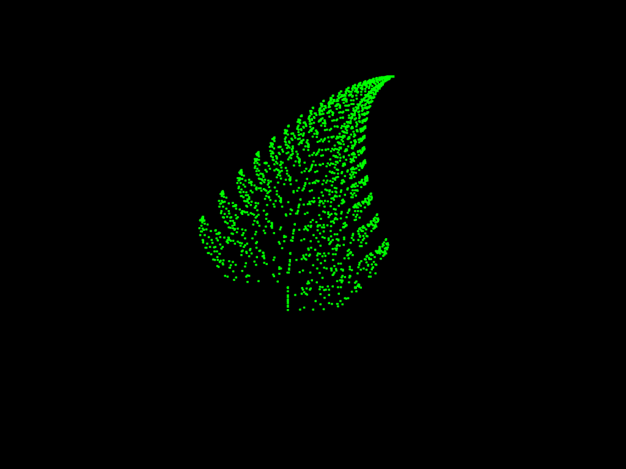

```r
a <- c(0, 0.85, 0.2, -0.15)
b <- c(0, 0.04, -0.26, 0.28)
c <- c(0, -0.04, 0.23, 0.26)
d <- c(0.16, 0.85, 0.22, 0.24)
e <- c(0, 0, 0, 0)
f <- c(0, 1.6, 1.6, 0.44)
numits <- 2000 # number of iterations
x <- 0
y <- 0

par(bg="black") # change the color for the background
plot(seq(-2, 10, by = 0.1), seq(-2, 10, by = 0.1), type = "n", main = "fractal fern")

for (n in seq(1, numits)){
  k <- sample(1:4, 1, replace = T, prob = c(0.01, 0.85, 0.07, 0.07))
  newx <- a[k]*x + b[k]*y + e[k]
  newy <- c[k]*x + d[k]*y + f[k]
  x <- newx
  y <- newy

  if (n > 10) points(x + 3, y, col = "green", cex = 0.5, pch = 20)
}
```

# Control Statements - 5

Here is another example for fractal tree

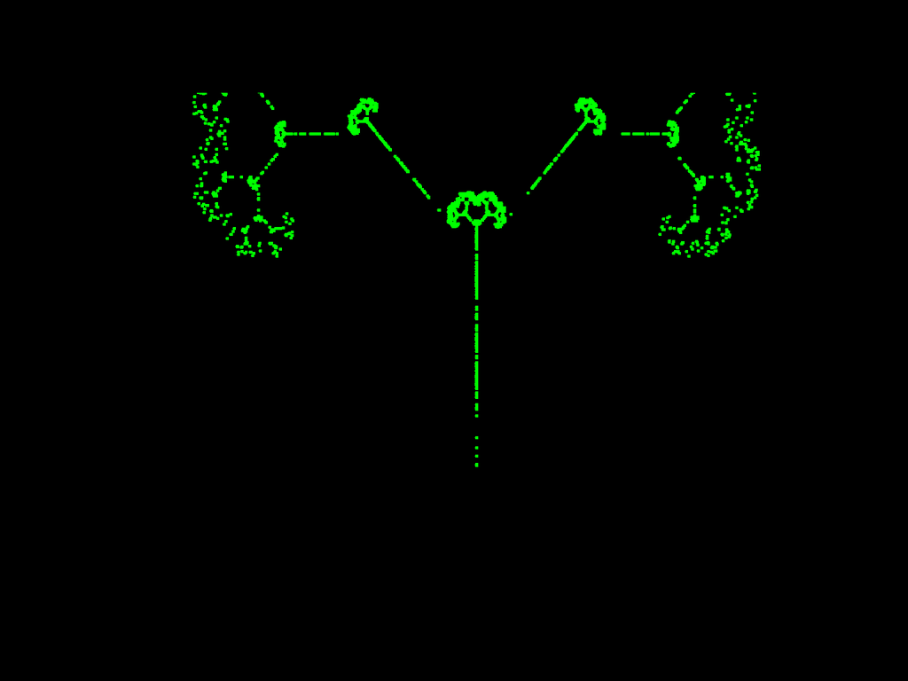

```r
a <- c(0, 0.42, 0.42, 0.1)
b <- c(0, -0.42, 0.42, 0)
c <- c(0, 0.42, -0.42, 0)
d <- c(0.5, 0.42, 0.42, 0.1)
e <- c(0, 0, 0, 0)
f <- c(0, 0.2, 0.2, 0.2)
numits <- 5000 # number of iterations
x <- 0
y <- 0

par(bg="black") # change the color for the background
plot(seq(-0.3, 0.3, by = 0.1), seq(0, 0.3, by = 0.05), type = "n", main = "fractal tree")

for (n in seq(1, numits)){
  k <- sample(1:4, 1, replace = T, prob = c(0.05, 0.4, 0.4, 0.15))
  newx <- a[k]*x + b[k]*y + e[k]
  newy <- c[k]*x + d[k]*y + f[k]
  x <- newx
  y <- newy

  if (n > 10) points(x, y, col = "green", cex = 0.5, pch = 20)
}
```

# Control Statements - 6

- Conditional Statements

Conditional statements can be very helpful when we only want to execute the commands under certain conditions.

### if-else statement

```
if (condition1){
    statements-1
}else{
    statements-2
}
```

```
if (condition1){
    statements-1
}else if (condition2){
    statements-2
}else{
    statements-3
}
```

### ifelse statement

When the logical statement is simple and short, it is convenient to use the ifelse() function.

```
ifelse(condition, true_value, false_value)
```

# Control Statements - 7

The following code chunk shows a simple example that examines a number is odd number or not.

```r
x <- 11
if (x%%2==1){
  print(paste(x, "is an odd number."))
}
```

```
## [1] "11 is an odd number."
```

Here is an improved version of the previous example.

```r
x <- 11
if (x%%2==1){
  print(paste(x, "is an odd number."))
}else{
  print(paste(x, "is an even number."))
}
```

```
## [1] "11 is an odd number."
```

```r
x <- sample(1:100, 10)
ifelse(x%%2 == 1, "Odd", "Even")
```

```
##  [1] "Odd"  "Even" "Odd"  "Even" "Odd"  "Odd"  "Even" "Even" "Even" "Odd"
```

# Control Statements - 8

**Example**: Give $n=100$, find $1\times 2+2\times 3 + \cdots + n\times (n+1)$.

```r
total_repeat <- 0
n <- 100
i <- 1
repeat{
  total_repeat <- total_repeat + i*(i+1)
  i <- i + 1
  if (i > n) break
}
total_repeat
```

```
## [1] 343400
```

**Example**: Read all csv files in a folder and check the dimension of each data file.

```
all_files <- list.files("C:/Users/tessa/Dropbox/MTH 209/Some Good Datasets", ".csv", full.names = T)

for (j in 1:length(all_files)){
  temp_file <- read_csv(all_files[j])
  print(dim(temp_file))
}
```

# Creation of Functions - 1

While we can use lots of functions in the R packages, there are some situations that we may want to define a function by ourselves. Using functions make our code well-organized and readable as well.

```
function_name <- function(arg1, arg2, ...){
    function body
}
```

In the following code chunk, we define a function to check if a value is an even number or odd number.

```r
check_numbers <- function(n){
  # n: an integer
  if (!(n%%2 %in% c(0,1))) return("The input value needs to be an integer.")
  if (n %% 2 == 1){
    return(paste(n, "is an odd number."))
  }else{
    return(paste(n, "is an even number."))
  }
}
check_numbers(2022)
```

```
## [1] "2022 is an even number."
```

```r
check_numbers(21.57)
```

```
## [1] "The input value needs to be an integer."
```

**Note**: Arguments are not required to create a function.

# Creation of Functions - 2

```r
squared <- function(x, a, opt_arg){
  # x: base value
  # a: exponent of x
  # opt_arg: optional argument

  if (missing(opt_arg)){
    new <- a*x^2
  }else{
    new <- a^x^2 + opt_arg
  }
  cat("This functon returns:", "\n")
  return(new)
}

squared(4, 5, 1024)
```

```
## This functon returns:
```

```
## [1] 152587891649
```

**Note**: The print() function returns a data object to the console and the cat function outputs a character string in a readable format.

# Creation of Functions - 3

**Fixed-Point Theorem**: a function $F$ will have at least one fixed point (a point $x$ such that $F(x)=x$) under some conditions on $F$.

```r
math_function <- function(x) sin(x) - 1
FPT_algorithm <- function(f, precision, x0, max_iter=20){
  # f: a function of one variable
  # precision: precision of the algorithm
  # x0: initial value
  # max_iter: maximum number of iterations
  error <- 5
  step <- 0
  while (error > precision & step < max_iter){
    step <- step + 1
    xn <- f(x0)
    error <- abs(xn-x0)
    x0 <- xn
  }
  if (step == max_iter){
    return(paste("We cannot find the root within", max_iter, "iterations."))
  }else{
    return(paste("The root is", x0, "and it takes", step, "iterations to obtain this root."))
  }
}
FPT_algorithm(math_function, 10^-5, 0.5, 100)
```

```
## [1] "The root is -1.93456536408994 and it takes 13 iterations to obtain this root."
```

```r
FPT_algorithm(cos, 10^-4, 0, 100)
```

```
## [1] "The root is 0.739054790746917 and it takes 24 iterations to obtain this root."
```

# Recursion - 1

- Can a function call itself?

Yes, it is called a recursive function. (A function within a function)

All recursive algorithms have the following steps:

1. Base step (when to stop)
2. Work toward base step
3. Recursive call

**A quote from [L. Peter Deutsch](https://en.wikipedia.org/wiki/L._Peter_Deutsch)**: To iterate is human, to recurse divine.

# Recursion - 2

**Example**: Use the recursive algorithm to define a function to calculate
$$1\times 2+ 2\times 3
+ \cdots + n\times (n+1).$$

```r
Rec_function <- function(n){
  if (n==1){
    return(1*2)
  }else{
    return(n*(n+1) + Rec_function((n-1)))
  }
}

Rec_function(100)
```

```
## [1] 343400
```

# Recursion - 3

**Example**: The Fibonacci numbers are numbers in the following sequence:
$$0, 1, 1, 2, 3, 5, 8,
13, 21, 34, \ldots$$
Let $F_n$ be the nth Fibonacci numbers. Then
$$Fn = F_{n-1} + F_{n-2}.$$
Write a recursive algorithm to find $F_n$.

```r
Fibonacci <- function(n){
  if (n==1){
    return(0)
  }else if (n==2){
    return(1)
  }else{
    return(Fibonacci(n-1)+Fibonacci(n-2))
  }
}

Fibonacci(7)
```

```
## [1] 8
```

```r
Fibonacci(20)
```

```
## [1] 4181
```

# README

You can utilize the following single character keyboard shortcuts to enable alternate display modes (Xie, Allaire, and Grolemund (2018)):

- A: Switches show of current versus all slides (helpful for printing all pages)
- B: Make fonts large
- c: Show table of contents
- S: Make fonts smaller

Matloff, Norman. 2011. *The Art of r Programming: A Tour of Statistical Software Design*. No Starch Press.

Xie, Yihui, Joseph J Allaire, and Garrett Grolemund. 2018. *R Markdown: The Definitive Guide*. CRC Press.